# Homeworrk #11

cuden

11/7/2018

For this final lab exerise, use your newly-developed ggplot chops to create some nice graphs from your own data (If you do not have a good data frame to use for graphics, use one of the many built-in data frames from R (other than mpg, which we are using in class)). Experiment with different themes, theme base sizes, aesthetics, mappings, and faceting. When you are finished, try exporting them to high quality pdfs, jpgs, eps files, or other formats that you would use for submission to a journal.

In this exercise, I encourage you to improve your graphics with elements that we have not (yet) covered in ggplot. For example, can you change the labels on a facet plot so that they are more informative than the variable names that are supplied from your data frame? Can you figure out how to add text annotations, lines and arrows to your graph? Can you figure out how to use custom colors that you have chosen for your fills and lines? Your resources for these explorations are google, Stack Overflow – and Lauren!

### Installing patchwork:

```r
#install.packages("devtools")
#devtools::install_github("thomasp85/patchwork")
#install.packages("patchwork")
library(patchwork)
library(ggplot2)

#example:
#p1 <- qplot(mtcars$mpg, mtcars$disp)
#p2 <- qplot(mtcars$mpg, mtcars$wt)
#p1 + p2 # Error: Don't know how to add p2 to a plot (if patchwork is not installed)

# installing packages for viridis and desaturating
#install.packages("colorspace", repos = "http://R-Forge.R-project.org")
#devtools::install_github("wilkelab/cowplot")
#devtools::install_github("clauswilke/colorblindr")
#library(colorblindr)
library(colorspace)
library(cowplot)
library(wesanderson)

# testing viridis
#fig <- ggplot(iris, aes(Sepal.Length, fill = Species)) + geom_density(alpha = 0.7)
#fig
```

### My Data:

For today’s assignment I will be using data on life stage transitions of centaurea (knapweed). Each row is a population of centaurea. Eventually, I will use this data to build population matrices, but right now I am just going to use ggplot to peek at the data.

Variables: g = germination rate (September - July) ss = seed survival (s-s) (Sept - July) ssj = survival of newly-germinated seedlings within first year (s-j) sjv = survival (maturation) of established seedlings to vegetative juveniles (j-v) sv = survival of vegetative juveniles (v-v) sf = survival of adult flowering plants (f-f) mjf = maturation, seedlings to flowering plants (j-f); probably unlikely mvf = maturation, vegetative juveniles to flowering plants (v-f) f = per capita fecundity (viable seeds)n

```r
C <- read.table("CentaureaVitalRates.csv",header=TRUE,sep=",", stringsAsFactors=FALSE)
#take out NA's
cleanC <- C[complete.cases(C[1:10]),]
```

### Plot 1:

To start, lets look at the relationship between species (spotted or meadow knapweed) and survival of adult flowering plants (sf), then plot it:

```r
head(cleanC)
```

```
##   Species  Location Area ss     g   ssj   sjv    sv  sf mjf   mvf     f
## 1 Spotted BlackPond    1  0 0.429 0.226 0.050 0.100 0.0   0 0.150 252.1
## 2 Spotted BlackPond    2  0 0.310 0.250 0.533 0.526 0.5   0 0.316 447.8
## 3 Spotted BlackPond    3  0 0.306 0.111 0.000 0.444 0.1   0 0.222 487.0
## 4 Spotted BlackPond    4  0 0.382 0.174 0.222 0.700 0.8   0 0.250 174.9
## 5 Spotted BlackPond    5  0 0.312 0.349 0.421 0.650 0.8   0 0.350 221.5
## 6 Spotted BlackPond    6  0 0.135 0.305 0.077 0.550 0.9   0 0.300 293.1
```

```r
ANOmodel <- aov(sf~Species, data=cleanC)
summary(ANOmodel)
```

```
##             Df Sum Sq Mean Sq F value   Pr(>F)
## Species      1  5.513   5.513   107.8 7.62e-15 ***
## Residuals   58  2.967   0.051
## ---
## Signif. codes:  0 '***' 0.001 '**' 0.01 '*' 0.05 '.' 0.1 ' ' 1
```

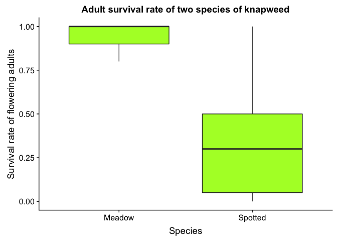

```r
p1 <- ggplot(data=cleanC,
             aes(x=Species, y=sf,
                 fill= I("greenyellow"))) +
  labs(title="Adult survival rate of two species of knapweed",
       y="Survival rate of flowering adults",
       x="Species") +
  geom_boxplot()
print(p1)
```

### Plot 2:

Another variable that may be related to survival is location. This also shows a significant relationship with survival.

```r
ANOmodel <- aov(sf~Location, data=cleanC)
summary(ANOmodel)
```

```
##             Df Sum Sq Mean Sq F value   Pr(>F)
## Location     6  6.619  1.1031    31.4 8.65e-16 ***
## Residuals   53  1.862  0.0351
## ---
## Signif. codes:  0 '***' 0.001 '**' 0.01 '*' 0.05 '.' 0.1 ' ' 1
```

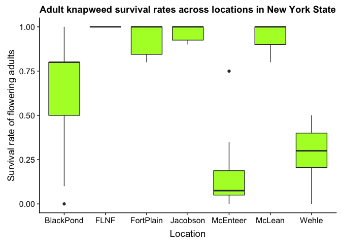

```r
p2 <- ggplot(data=cleanC,
             aes(x=Location, y=sf,
                 fill= I("greenyellow"))) +
  labs(title="Adult knapweed survival rates across locations in New York State",
       y="Survival rate of flowering adults",
       x="Location") +
  geom_boxplot()
print(p2)
```

### Plot 3

I am going to try combining all of this information onto one plot: location x survival with species in color.

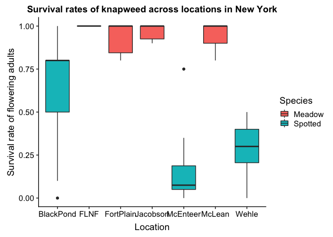

```r
p3 <- ggplot(data=cleanC,
             mapping=aes(x=Location, y=sf, fill=Species)) +
  labs(title="Survival rates of knapweed across locations in New York",
       y="Survival rate of flowering adults",
       x="Location") +
  geom_boxplot()
print(p3)
```

### Plots 4 and 5

plotting all locations and species on one graph doesn’t make sense -you can’t conclude anything about the environmental versus genetic componenets of survival.

Instead, we need to look at variation in survival rates within species, at different locations. I’m going to use patchwork to put them together… because I can.

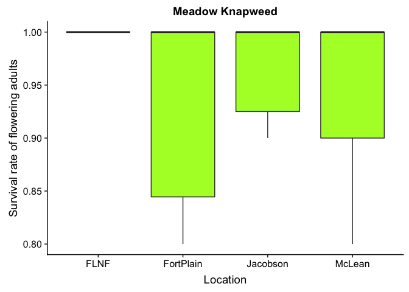

```r
p4 <- ggplot(data=cleanC,
             mapping=aes(x=Location, y=sf, fill= I("greenyellow"))) +
  labs(title="Meadow Knapweed",
       y="Survival rate of flowering adults",
       x="Location") +
  geom_boxplot(data=cleanC[cleanC$Species=="Meadow",])
print(p4)
```

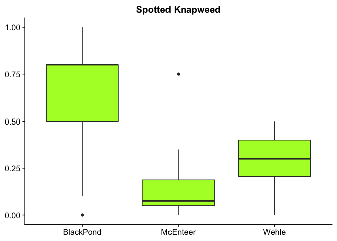

```r
p5 <- ggplot(data=cleanC,
             mapping=aes(x=Location, y=sf, fill= I("greenyellow"))) +
  labs(title="Spotted Knapweed",
       y=NULL,
       x=NULL) +
  geom_boxplot(data=cleanC[cleanC$Species=="Spotted",])
print(p5)
```

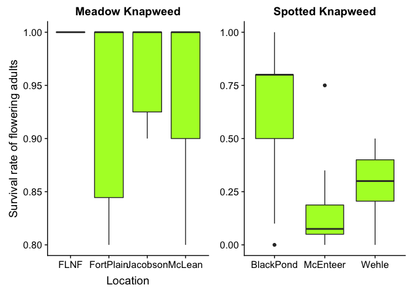

```r
p4 + p5
```

Or, I could use the facet funciton:

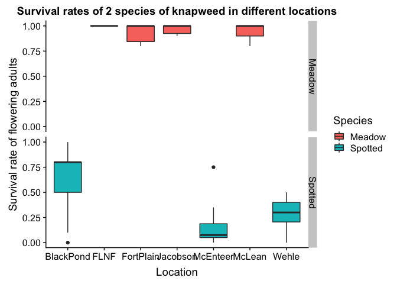

```r
p6 <- ggplot(data=cleanC,
             mapping=aes(x=Location, y=sf, fill=Species)) +
    labs(title="Survival rates of 2 species of knapweed in different locations",
       y="Survival rate of flowering adults",
       x="Location") +
  geom_boxplot() +
  facet_grid(Species~.)
print(p6)
```

Again, becuase both species weren’t measured at each locaion, plotting the data this way is less helpful than having separate plots for each species. So, I’m going to focus on making plots 4 and 5 look pretty.

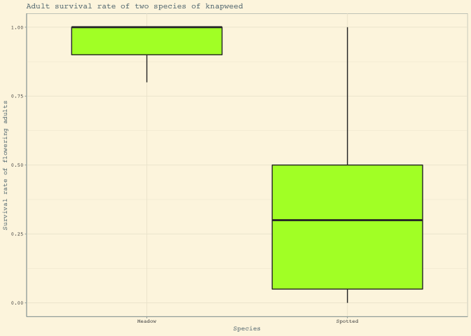

```r
library(ggthemes)
p1 <- p1 + theme_solarized(base_size=7, base_family="Courier")
print(p1)
```

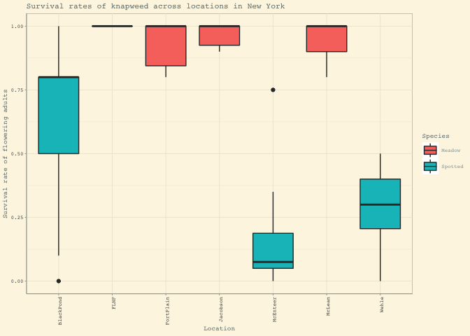

```r
p2 <- p2 + theme_solarized(base_size=7, base_family="Courier") + theme(axis.text.x = element_text(angle = 90, hjust = 1))
p3 <- p3 + theme_solarized(base_size=7, base_family="Courier")  + theme(axis.text.x = element_text(angle = 90, hjust = 1))
print (p3)
```

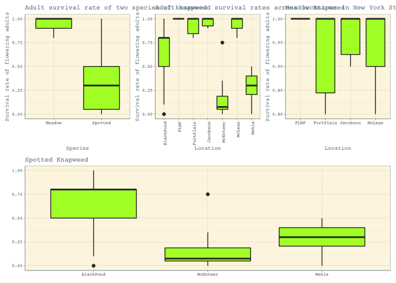

```r
p4 <- p4 + theme_solarized(base_size=7, base_family="Courier")
p5 <- p5 + theme_solarized(base_size=7, base_family="Courier")

(p1 | p2 | p4)/p5
```

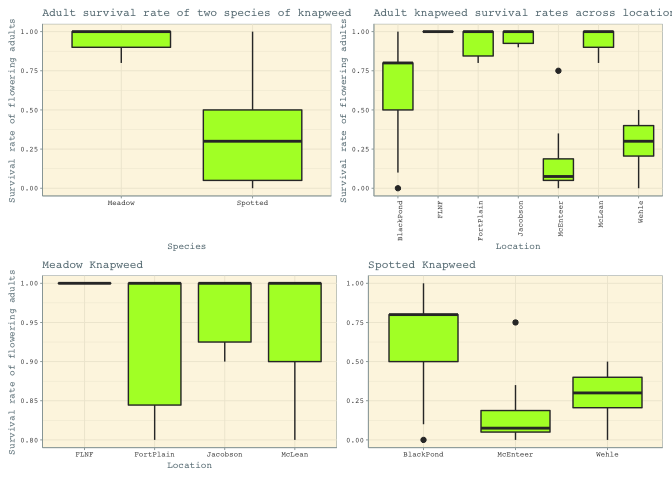

```r
(p1 | p2)/(p4 | p5)
```

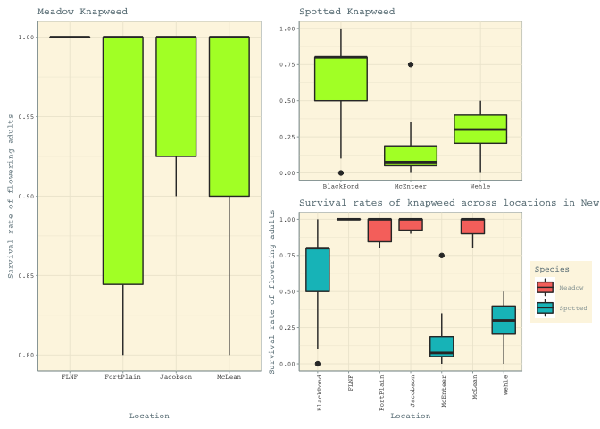

```r
p4 | p5 + {
  p3
} + plot_layout(ncol=1)
```

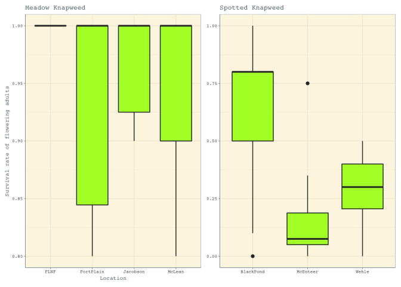

```r
p4 + p5
```

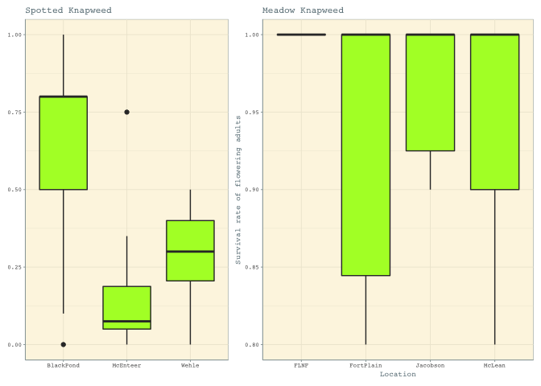

```r
p5 + p4 + plot_layout(ncol=2, widths=c(3,4))
```